# Week 6 Matching, Propensity Scores, and Weighting

Author

Zhe Chen

# What Regression Gives $\bigstar$

Naive comparison:

$$\begin{aligned}
E[Y_i\mid D_i=1]-E[Y_i\mid D_i=0]
&= \tau
+\underbrace{
E[Y_i(0)\mid D_i=1]-E[Y_i(0)\mid D_i=0]
}_{\text{selection on the baseline }Y_i(0)} \\[12pt]
&\quad+
\underbrace{
(1-\pi)(\mathrm{ATT}-\mathrm{ATU})
}_{\text{selection on the effect }\tau_i}.
\end{aligned}$$

Regress $Y$ on $D$ and $X, under conditional ignorability

$$E[Y_i\mid D_i=1,X_i=x]-E[Y_i\mid D_i=0,X_i=x]=\tau(x)
\qquad \text{Week 5's }CATE(x)$$
**selection problem is removed within that cell, but the treatment effect can still differ across cells.**

$$\tau(x_1)\neq \tau(x_2)$$

## ATE, ATT, and ATU $\bigstar$

$$\begin{aligned}
ATE &= \sum_x \tau(x)\Pr(X_i=x) && \text{everyone: a universal policy}\\
ATT &= \sum_x \tau(x)\Pr(X_i=x\mid D_i=1) && \text{the treated: what treatment did for them}\\
ATU &= \sum_x \tau(x)\Pr(X_i=x\mid D_i=0) && \text{the untreated: what it would do for them}
\end{aligned}$$

**Tip**

The ATE is the weighted average of those heterogeneous CATE(x).

## Why OLS Fails $\bigstar$

**Tip**

A related paper on this problem

Aronow, P.M. and Samii, C. (2016), Does Regression Produce Representative Estimates of Causal Effects?. *American Journal of Political Science*, 60: 250-267. https://doi.org/10.1111/ajps.12185

OLS of $Y_i$ on $D_i$ and a saturated $X_i$ returns one coefficient. It too is an average of the $\tau(x)$, but with weights OLS picks, where $e(x)=\Pr(D_i=1\mid X_i=x)$:

$$\tau_R=\frac{\sum_x \tau(x)e(x)(1-e(x))\Pr(X_i=x)}{\sum_x e(x)(1-e(x))\Pr(X_i=x)}
\qquad \text{weight: the variance of treatment in the cell}$$

**Warning**

$\tau_R$ is none of the three targets unless $\tau(x)$ is constant

**Noteproof of $\tau_R$**

Set saturated controls as $f(X_i)$, the propensity of being treated as $e(x)=\Pr(D_i=1\mid X_i=x)$

$$Y_i=\alpha+\tau_R D_i+f(X_i)+\varepsilon_i$$

Based on FWL theorem

$$\widetilde D_i=D_i-E[D_i\mid X_i]=D_i-e(X_i)$$

$$\widetilde Y_i=Y_i-E[Y_i\mid X_i]$$

$$\tau_R=\frac{E[\widetilde D_i\widetilde Y_i]}{E[\widetilde D_i^2]}=\frac{E[\widetilde D_iY_i]}{E[\widetilde D_i^2]}$$
Denominator

$$E[\widetilde D_i^2]=\sum_x E[(D_i-e(x))^2\mid X_i=x]\Pr(X_i=x)$$

$$E[(D_i-e(x))^2\mid X_i=x]=e(x)(1-e(x))^2+(1-e(x))e(x)^2=e(x)(1-e(x))$$

$$E[\widetilde D_i^2]=\sum_x e(x)(1-e(x))\Pr(X_i=x)$$

Numerator:

$$E[\widetilde D_iY_i]= E[(D_i - e(X_i)Y_i)]= \sum_x E[(D_i-e(x))Y_i\mid X_i=x]\Pr(X_i=x)$$

$$\begin{aligned} &E[(D_i-e(x))Y_i\mid X_i=x]\\ &=e(x)(1-e(x))E[Y_i\mid D_i=1,X_i=x]\\ &\quad-e(x)(1-e(x))E[Y_i\mid D_i=0,X_i=x]\\ &=e(x)(1-e(x))\left(E[Y_i\mid D_i=1,X_i=x]-E[Y_i\mid D_i=0,X_i=x]\right) \end{aligned}$$

Set $\tau(x)=E[Y_i\mid D_i=1,X_i=x]-E[Y_i\mid D_i=0,X_i=x]$

Then

$$E[\widetilde D_iY_i]=\sum_x\tau(x)e(x)(1-e(x))\Pr(X_i=x)$$

Finally

$$\tau_R=\frac{\sum_x\tau(x)e(x)(1-e(x))\Pr(X_i=x)}{\sum_x e(x)(1-e(x))\Pr(X_i=x)}$$
Or

$$\tau_R=\sum_x\tau(x)\frac{e(x)(1-e(x))\Pr(X_i=x)}{\sum_{x'}e(x')(1-e(x'))\Pr(X_i=x')}, \qquad w(x)=\frac{e(x)(1-e(x))\Pr(X_i=x)}{\sum_{x'}e(x')(1-e(x'))\Pr(X_i=x')}$$
$w(x)$ is the variance of treatment in the cell

$$\begin{aligned}
\operatorname{Var}(D_i\mid X_i=x)
&=E[D_i^2\mid X_i=x]-(E[D_i\mid X_i=x])^2\\
&=e(x)-e(x)^2\\
&=e(x)(1-e(x)).
\end{aligned}$$

$$\begin{aligned}
w(x)
&=\frac{e(x)(1-e(x))\Pr(X_i=x)}
{\sum_{x'}e(x')(1-e(x'))\Pr(X_i=x')}\\
&=\frac{\operatorname{Var}(D_i\mid X_i=x)\Pr(X_i=x)}
{\sum_{x'}\operatorname{Var}(D_i\mid X_i=x')\Pr(X_i=x')}.
\end{aligned}$$

$$w(x)\propto\operatorname{Var}(D_i\mid X_i=x)\Pr(X_i=x)$$

# Matching

## Exact Matching $\bigstar$

$$\hat{\tau}(x)=\bar{Y}_{1x}-\bar{Y}_{0x},\qquad \widehat{ATE}=\sum_x\frac{n_x}{n}\hat{\tau}(x)\qquad \text{where }n_x\text{ is the number of units in cell }x$$

- Each treated unit is compared only with untreated units that share its $X_i$. Under ignorability $\hat{\tau} (X_i)$ estimates $\tau(X_i)$
- **Requirement: a cell needs both arms**

### Responses to unmatched cells $\bigstar$

1. **Drop the cell**：The estimand becomes the ATE on the matched population, $\sum_x \tau(x)\Pr(X_i=x\mid \mathrm{matched})$. Report the share of units, and of treated units, that were dropped, and what those cells look like.
2. **Coarsen**: Merge the cell with its neighbors. Merged cells hold both arms more often, at the price of comparing units that differ within a band: a bias you then check (two frames on).
3. **Model**: Predict $\bar{Y}_{0x}$ for the cell from nearby cells. This is regression’s answer, and it is extrapolation: right only if the model is, and untestable where the data are absent.

## Checks for the ATE $\bigstar$

- **Coverage**: How many treated and untreated units sit in matched cells, and which cells were lost. This is the common-support check in its most transparent form.
- **Balance inside the cells**: Variables matched on exactly agree within every cell by construction. Variables you coarsened do not. For each such variable take the treated–untreated gap within each matched cell, average the gaps over cells with the ATE weights $n_x/n$, and divide by the pooled SD: the standardized mean difference, with 0.1 the usual bar. Do the same for variables you did not match on at all.
- **Representativeness**: Compare the matched population’s cell shares with the full sample’s. If dropping cells changed whom you describe, say so.

## Matching for the ATT $\bigstar$

$$\widehat{ATT}=\sum_x\frac{n_{1x}}{n_1}\hat{\tau}(x)\qquad \text{where }n_{1x}\text{ is the number treated in cell }x,\text{ and }n_1\text{ is the number treated in matched cells}$$

- Keep every treated unit. In each treated cell, weight the untreated units so that, cell by cell, the untreated look like the treated. The treated themselves are never reweighted.
- **Asymmetry**. Untreated units in cells with no treated unit go unused at no cost. Treated units in cells with no untreated unit are the problem: dropping them makes it the effect on the matchable treated.
- **Checks**:
  - Coverage: share of treated dropped.
  - Balance: reweighted untreated against the treated, the treated SD as yardstick.
  - Variance: how many untreated units each treated cell draws on.
- Positivity is needed only where the treated are: $e(x) < 1$ suffices.

## The Curse of Dimensionality $\bigstar$

Exact matching becomes impossible when there are too many cells.

Responses

- **Coarsened exact matching (CEM)**: bin continuous covariates coarsely, then match exactly on the bins.
- **Nearest-neighbour matching** on a distance
- **Propensity score matching**: collapse $X$ to a single number

## Matching Is Preprocessing, Not Estimation $\bigstar$

Matching is a *nonparametric preprocessing step* that reduces how much your final model has to do.

**Steps for estimation**

1. Match, using no outcome data at all. This is the design stage; it can be iterated freely without p-hacking, because you cannot see the answer.
2. Check coverage and balance, as above: standardized mean differences below 0.1, variance ratios near 1, density overlaps.
3. Then run your estimate on the matched sample.

## Standard Error of a Matching Estimate

### Cells

$$\begin{aligned}
\widehat{ATE} &= \sum_x \frac{n_x}{n}\hat{\tau}(x) && \text{each }\hat{\tau}(x)\text{ is a difference of two means}\\
\widehat{\operatorname{Var}}(\widehat{ATE}) &= \sum_x\left(\frac{n_x}{n}\right)^2\left(\frac{s_{1x}^2}{n_{1x}}+\frac{s_{0x}^2}{n_{0x}}\right) && \text{ATT: weights }n_{1x}/n_1
\end{aligned}$$

- **Bootstrap**. Resample units, rebuild the cells, recompute.
- **The regression route**. Weighted regression of Y on D with the matching weights gives the same estimate. **Do not cluster by cell: cells are strata, not dependence.**

### Nearest-Neighbor Matching

With $K_j$ uses of control $j$,

$$\operatorname{Var}(\widehat{ATT})=\frac{1}{n_1^2}\left[\sum_{\mathrm{treated}}\sigma_1^2(X_i)+\sum_{\mathrm{controls}}K_j^2\sigma_0^2(X_j)\right].$$

- Ordinary bootsrap fails
- `Matching::Match()` prints the formula above.

### What to Actually Do

| Estimator | Standard error |
| --- | --- |
| **Exact or coarsened cells** | Cell formula, or weighted regression of $Y$ on $D$ with matching weights and a robust sandwich (`vcovHC`). Not clustered by cell. |
| **Nearest neighbour, without replacement** | Weighted regression on `match.data()`, sandwich clustered by matched pair (`cluster = ~subclass`). No bootstrap. |
| **Nearest neighbor, with replacement** | `get_matches()`, so a reused control appears once per use; sandwich clustered by pair and person (`~subclass + id`), or `Matching::Match()` for the Abadie–Imbens variance. No bootstrap. |
| **Weighting (ATE, ATT, ATO)** | Weighted regression with a robust sandwich, treating $\hat e$ as known; bootstrap the entire pipeline, including logit, to account for its estimation. |
| **AIPW** | Influence function: SD of the $n$ terms divided by $\sqrt{n}$; the pipeline bootstrap agrees. |

### Practical Lessons for Matching

1. Define the treatment before you match. “Ever lived with” and “born to” are different populations with different answers; the first mixes in the effect of separation.
2. Measure covariates before the treatment.
3. Show the selection, so the reader knows which way the raw gap is biased.
4. Report what pruning did: cells kept, controls set aside, whether any treated unit was lost.
5. Regression beside matching checks model dependence, not ignorability. The causal claim rests on the bounds, and on saying what they assume: that observed selection is informative about unobserved selection.

# Propensity Score

## Definition $\bigstar$

The propensity score

$$e(x)\equiv\Pr(D_i=1\mid X_i=x).$$

**Rosenbaum and Rubin (1983)**

If

$$(Y_i(0),Y_i(1))\perp\!\!\!\perp D_i\mid X_i,$$

then

$$(Y_i(0),Y_i(1))\perp\!\!\!\perp D_i\mid e(X_i).$$

- A p-dimensional matching problem collapses to a one-dimensional one.
- $e(X)$ is a balancing score: within strata of $e(X)$, the whole covariate vector is distributed identically in the two groups.
- **It does nothing about unobserved confounders.**

## Estimation and Checks $\bigstar$

- Usually a logit of $D$ on $X$. **This logit model is not judged by fit.** A propensity model with a high AUC (Area Under the ROC Curve) is often a bad sign, it means treated and control units are easy to tell apart, i.e. poor overlap.
- Judge it by balance: does weighting or matching on $\hat{e}$ equalize the covariate distributions? Iterate on the specification until it does, adding interactions and polynomials as needed.
- Plot the two distributions of $\hat{e}$. Mass near 0 among the treated, or near 1 among the controls, is a positivity failure staring at you.

**WarningThe propensity score paradox**

The better your propensity model predicts treatment, the less common support you have, and the less the data can tell you. Prediction quality and identification pull in opposite directions.

## Overlap: What to Do When It Fails $\bigstar$

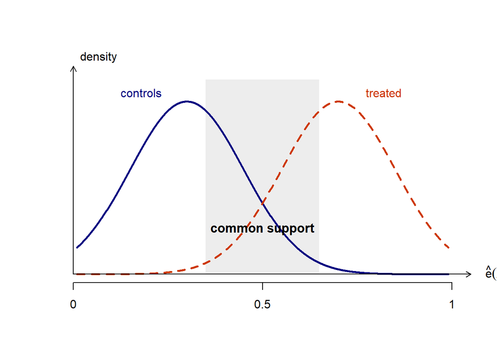

- **Trim to a range of** $\hat{e}$ (say [0.1, 0.9]), and say so. You have changed the estimand to that subpopulation.
- **Redefine the population** to the region where comparison is possible, often the honest and more interesting move
- **Change the estimand**: the ATT needs overlap only for the treated; the “overlap-weighted” estimand (Li, Morgan, and Zaslavsky 2018), deliberately targets the region where comparison is best.

# Weighting $\bigstar$

## Why Weighting after Matching

- **It is the same operation**. Matching’s ATT gave each untreated unit in cell $x$ the weight $n_{1x}/n_{0x}$. Weighting gives it $e(x)/(1 − e(x))$: the same ratio with a model in place of the count. Both average $\tau (x)$ with the target’s weights.
- **What weighting buys**: A one-armed or empty cell is not dropped. Every unit is used, continuous X and many covariates are no obstacle, one formula serves every target, and it plugs into the doubly robust estimator.
- **What weighting costs**: Thin overlap does not disappear; it moves. Matching drops a treated unit with no comparison and says so. Weighting keeps it at weight $1/\hat{e}$ = 100 and says so only through the variance and the largest weights; and the weights are right only where the model is, including where the data are too thin to check.

**The trade**

- Matching narrows the target and says so - Weighting keeps the target and pays in variance and model dependence.

## ATT in Weighting $\bigstar$

In cell $x$, $n_{1x}/n_{0x}$ estimates $\Pr(D_i=1\mid x)/\Pr(D_i=0\mid x)=e(x)/(1-e(x))$, the *odds of treatment*. So matching’s ATT weights were, in population terms:

$$\text{treated: }1,\qquad \text{untreated: }\frac{e(X_i)}{1-e(X_i)}.$$

**Note**

Intuitively, ATT weighting makes untreated individuals resemble the treated population by giving more weight to controls from cells where treatment is more common.

For the ATT, we want to estimate the counterfactual outcomes of the treated population.

The matching weights are:

$$w_i=\begin{cases}1,&D_i=1\\ \dfrac{n_{1x}}{n_{0x}},&D_i=0,\ X_i=x.\end{cases}$$

Within a cell $x$, the treatment probability is $\hat{e}(x) = n_{1x}/(n_{1x}+n_{0x})$

$$\frac{\hat e(x)}{1-\hat e(x)}=\frac{n_{1x}/(n_{1x}+n_{0x})}{n_{0x}/(n_{1x}+n_{0x})}=\frac{n_{1x}}{n_{0x}}$$
Thus, in population terms, the ATT weights are

$$\boxed{w_i^{ATT}=\begin{cases}1,&D_i=1\\ \dfrac{e(X_i)}{1-e(X_i)},&D_i=0.\end{cases}}$$

**NoteCheck that the weighted untreated mean is the treated group’s counterfactual:**

$$\begin{aligned}
E\left[\frac{e(X_i)}{1-e(X_i)}(1-D_i)Y_i\right]
&=E\left[\frac{e(X_i)}{1-e(X_i)}E[(1-D_i)Y_i(0)\mid X_i]\right] && \text{iterate on }X_i\\
&=E\left[\frac{e(X_i)}{1-e(X_i)}(1-e(X_i))E[Y_i(0)\mid X_i]\right] && \text{ignorability}\\
&=E\left[e(X_i)E[Y_i(0)\mid X_i]\right] && \text{cancel}\\
&=E[D_iY_i(0)]=\pi E[Y_i(0)\mid D_i=1] && e(X_i)=E[D_i\mid X_i],\ \text{iterate}
\end{aligned}$$

Divide by $\pi=E[D_i]$, which is what the weights sum to. The treated need no weights: $E[D_iY_i]/\pi=E[Y_i(1)\mid D_i=1]$. Subtract: the ATT.

## ATE in Weighting $\bigstar$

Now the target is everyone. Cell $x$ holds $n_x$ units, of which $n_{1x}$ are treated; for the treated to stand in for the whole cell, each must count $n_x/n_{1x}$ times, which estimates $1/e(x)$. Likewise each untreated unit counts $1/(1-e(x))$:

$$\boxed{\widehat{ATE}_{\mathrm{IPW}}=\frac{1}{n}\sum_{i=1}^{n}\left[\frac{D_iY_i}{\hat e(X_i)}-\frac{(1-D_i)Y_i}{1-\hat e(X_i)}\right]}$$

Rare treated units in a cell count for more, because they stand in for everyone like them who was not treated.

**Note**

**1. Derivation from Covariate Cells**

Define the estimated propensity score within cell $x$:

$$\hat e(x)=\frac{n_{1x}}{n_x},\qquad 1-\hat e(x)=\frac{n_{0x}}{n_x}$$

Therefore, the inverse probability weights are:

$$\frac{1}{\hat e(x)}=\frac{n_x}{n_{1x}},\qquad \frac{1}{1-\hat e(x)}=\frac{n_x}{n_{0x}}$$

**Step 1: Weighted treated outcomes**

$$\begin{aligned}
\frac{1}{n}\sum_{i:X_i=x}\frac{D_iY_i}{\hat e(x)}
&=\frac{1}{n}\frac{n_x}{n_{1x}}\sum_{i:X_i=x,D_i=1}Y_i\\
&=\frac{n_x}{n}\left(\frac{1}{n_{1x}}\sum_{i:X_i=x,D_i=1}Y_i\right)\\
&=\frac{n_x}{n}\bar Y_{1x}
\end{aligned}$$

**Step 2: Weighted untreated outcomes**

$$\begin{aligned}
\frac{1}{n}\sum_{i:X_i=x}\frac{(1-D_i)Y_i}{1-\hat e(x)}
&=\frac{1}{n}\frac{n_x}{n_{0x}}\sum_{i:X_i=x,D_i=0}Y_i\\
&=\frac{n_x}{n}\left(\frac{1}{n_{0x}}\sum_{i:X_i=x,D_i=0}Y_i\right)\\
&=\frac{n_x}{n}\bar Y_{0x}
\end{aligned}$$

**Step 3: Subtract and aggregate across cells**

$$\begin{aligned}
\widehat{ATE}_{IPW}
&=\sum_x\frac{n_x}{n}\left(\bar Y_{1x}-\bar Y_{0x}\right)\\
&=\frac{1}{n}\sum_{i=1}^n\left[\frac{D_iY_i}{\hat e(X_i)}-\frac{(1-D_i)Y_i}{1-\hat e(X_i)}\right]
\end{aligned}$$

**2. Population Identification Proof**

Assume consistency, conditional ignorability, and positivity.

**Step 1: Identify the treated potential outcome mean**

$$\begin{aligned}
E\left[\frac{D_iY_i}{e(X_i)}\right]
&=E\left[\frac{D_iY_i(1)}{e(X_i)}\right] && \text{consistency}\\
&=E\left[\frac{E[D_iY_i(1)\mid X_i]}{e(X_i)}\right] && \text{iterated expectations}\\
&=E\left[\frac{E[D_i\mid X_i]E[Y_i(1)\mid X_i]}{e(X_i)}\right] && \text{ignorability}\\
&=E\left[\frac{e(X_i)E[Y_i(1)\mid X_i]}{e(X_i)}\right] && \text{definition of propensity score}\\
&=E[E[Y_i(1)\mid X_i]] && \text{cancel}\\
&=E[Y_i(1)] && \text{iterated expectations}
\end{aligned}$$

**Step 2: Identify the untreated potential outcome mean**

$$\begin{aligned}
E\left[\frac{(1-D_i)Y_i}{1-e(X_i)}\right]
&=E\left[\frac{(1-D_i)Y_i(0)}{1-e(X_i)}\right] && \text{consistency}\\
&=E\left[\frac{E[(1-D_i)Y_i(0)\mid X_i]}{1-e(X_i)}\right] && \text{iterated expectations}\\
&=E\left[\frac{E[1-D_i\mid X_i]E[Y_i(0)\mid X_i]}{1-e(X_i)}\right] && \text{ignorability}\\
&=E\left[\frac{(1-e(X_i))E[Y_i(0)\mid X_i]}{1-e(X_i)}\right]\\
&=E[E[Y_i(0)\mid X_i]]\\
&=E[Y_i(0)]
\end{aligned}$$

**Step 3: Subtract to identify ATE**

$$\begin{aligned}
ATE
&=E[Y_i(1)-Y_i(0)]\\
&=E[Y_i(1)]-E[Y_i(0)]\\
&=E\left[\frac{D_iY_i}{e(X_i)}\right]-E\left[\frac{(1-D_i)Y_i}{1-e(X_i)}\right]\\
&=\boxed{E\left[\frac{D_iY_i}{e(X_i)}-\frac{(1-D_i)Y_i}{1-e(X_i)}\right]}
\end{aligned}$$

$$E\left[\frac{D_iY_i}{e(X_i)}\right]=E\left[\frac{E[D_i\mid X_i]E[Y_i(1)\mid X_i]}{e(X_i)}\right]=E\left[E[Y_i(1)\mid X_i]\right]=E[Y_i(1)],$$

by ignorability given $X_i$ and then iterated expectations; the same for the untreated arm with $1-e$. $\blacksquare$

This is the Horvitz–Thompson estimator of survey sampling, with treatment assignment as the sampling mechanism.

## ATO in Weighting $\bigstar$

Cell $x$ holds $n_{1x}=e(x)n_x$ treated and $n_{0x}=(1-e(x))n_x$ untreated units. Give each treated unit the weight $1-e(x)=n_{0x}/n_x$, the share of its cell it can be compared with, and each untreated unit $e(x)=n_{1x}/n_x$. Then in every cell

$$\underbrace{n_{1x}\frac{n_{0x}}{n_x}}_{\text{treated total}}=\frac{n_{1x}n_{0x}}{n_x}=\underbrace{n_{0x}\frac{n_{1x}}{n_x}}_{\text{untreated total}}.$$

- **Balanced by construction:** both arms carry the same total weight in every cell. Bounded: no weight exceeds 1.
- **Whom it describes:** Cell $x$ counts in proportion to $n_{1x}n_{0x}/n_x=n_xe(x)(1-e(x))$, the comparisons it affords: a one-armed cell drops out on its own, a half-and-half cell counts most. The target is “people for whom the data contain a comparison,” the *overlap population*, ATO.
- $n_xe(x)(1-e(x))$ is slide 6’s regression weighting: ATO is what saturated OLS targeted all along, now chosen deliberately.

**Note**

Let $D_i\in\{0,1\}$ and $e(x)=\Pr(D_i=1\mid X_i=x)$. In cell $x$, there are $n_{1x}=n_xe(x)$ treated and $n_{0x}=n_x(1-e(x))$ untreated observations.

**Step 1. Construct overlap weights.**

Assign each observation the weight

$$\omega_i=
\begin{cases}
1-e(x), & D_i=1,\\
e(x), & D_i=0.
\end{cases}$$

The total weight in each treatment arm is

$$\begin{aligned}
W_{1x}
&=n_{1x}(1-e(x))\\
&=\frac{n_{1x}n_{0x}}{n_x}\\
&=n_{0x}e(x)=W_{0x}.
\end{aligned}$$

Thus, overlap weighting achieves exact within-cell balance.

**Step 2. Derive the cell weights.**

Because $D_i$ is binary,

$$\begin{aligned}
\operatorname{Var}(D_i\mid X_i=x)
&=E[D_i^2\mid X_i=x]
-(E[D_i\mid X_i=x])^2\\
&=e(x)-e(x)^2\\
&=e(x)(1-e(x)).
\end{aligned}$$

Therefore, the total weight per arm in cell $x$ is

$$\boxed{
a_x=n_xe(x)(1-e(x))
=n_x\operatorname{Var}(D_i\mid X_i=x).
}$$

**Step 3. Establish equivalence to saturated OLS.**

Let $\widehat{\tau}(x)=\overline Y_{1x}-\overline Y_{0x}$. The overlap-weighted mean difference is

$$\widehat{\tau}_{OW}
=\frac{\sum_xa_x\widehat{\tau}(x)}{\sum_xa_x}.$$

For the saturated regression

$$Y_i=\alpha_{X_i}+\tau_R D_i+\varepsilon_i,$$

the FWL theorem gives

$$\widehat{\tau}_R
=\frac{\sum_i(D_i-e(X_i))Y_i}
{\sum_i(D_i-e(X_i))^2}.$$

Within each cell,

$$\begin{aligned}
\sum_{i:X_i=x}(D_i-e(x))Y_i
&=a_x\widehat{\tau}(x),\\
\sum_{i:X_i=x}(D_i-e(x))^2
&=a_x.
\end{aligned}$$

Hence,

$$\boxed{
\widehat{\tau}_R
=\frac{\sum_xa_x\widehat{\tau}(x)}{\sum_xa_x}
=\widehat{\tau}_{OW}.
}$$

This sample equality uses empirical within-cell propensity scores and requires positive total within-cell treatment variation.

**Step 4. Identify the causal estimand.**

Under consistency, conditional exchangeability, and positivity, the population coefficient is

$$\begin{aligned}
\tau_R
&=\frac{\sum_x e(x)(1-e(x))\Pr(X_i=x)\tau(x)}
{\sum_x e(x)(1-e(x))\Pr(X_i=x)}\\
&=\boxed{ATO}.
\end{aligned}$$

Thus, saturated OLS implicitly targets the overlap population, while overlap weighting targets it explicitly.

## Full Table $\bigstar$

$$\begin{array}{llll}\hline
\text{Target} & \text{Weight on treated} & \text{Weight on untreated} & \text{Who is reweighted}\\ \hline
\text{ATE} & 1/e(X) & 1/(1-e(X)) & \text{both, to the population}\\
\text{ATT} & 1 & e(X)/(1-e(X)) & \text{the untreated, to the treated}\\
\text{ATU} & (1-e(X))/e(X) & 1 & \text{the treated, to the untreated}\\
\text{Overlap (ATO)} & 1-e(X) & e(X) & \text{both, to where they overlap}\\ \hline
\end{array}$$

## IPW is a Weighted Regression

Define the **Horvitz–Thompson transformation**:

$$H_i=\frac{D_i}{e(X_i)}-\frac{1-D_i}{1-e(X_i)}.$$

Then $E[H_iY_i]=E[Y_i(1)-Y_i(0)]$: **the ATE weights of the last frame in one term.**

Equivalently: The coefficient on $D_i$ from a weighted least squares regression of $Y_i$ on $D_i$ (with an intercept), **using weights** $1/\hat e(X_i)$ **for the treated and** $1/(1-\hat e(X_i))$ **for the controls,** is a difference in weighted means with the weights normalized to sum to one in each arm (the Hájek form), rather than the raw average that divides by $n$.

- **Practically convenient:** `lm(y ~ d, weights = w)` runs IPW, and covariates can be added for extra protection.
- **Conceptually important:** weighting and regression are one continuum, and this is the bridge to the doubly robust estimator.

## Stabilized Weights

The ATE weights $1/e$ and $1/(1-e)$ sum to about $n$ per arm. The *stabilized weight* multiplies by the arm’s share, $\pi=\Pr(D_i=1)$:

$$w_i^S=\frac{\Pr(D_i=d)}{\Pr(D_i=d\mid X_i)}
=\begin{cases}
\pi/e(X_i), & D_i=1\\
(1-\pi)/(1-e(X_i)), & D_i=0.
\end{cases}$$

From here on $w_i$ means $w_i^S$.

- **What changes: the scale.** The weights now sum to about $n_1$ and $n_0$ and average 1. A mean far from 1 says the model for $e$ is off.
- **What does not change: everything relative.** Within an arm every weight is multiplied by the same constant, so the weighted mean $\sum_i w_iY_i/\sum_i w_i$ is the same, and the unit with $\hat e=0.01$ still counts 100 times its neighbors.

## Effective Sample Size

A weighted mean is as noisy as an *unweighted* mean of $n = ESS$ units.

$$ESS=\frac{\left(\sum_i w_i\right)^2}{\sum_i w_i^2}$$

**The direction:** the more unequal the weights, the smaller the ESS, from $n$ (all equal) down to $1$ (one unit has it all). The average inherits the heaviest unit’s noise, and the others cannot average it away.

$$\begin{array}{lc}\hline
\text{Four units, weights} & ESS\\ \hline
0.25,\ 0.25,\ 0.25,\ 0.25 & 4.0\\
0.40,\ 0.20,\ 0.20,\ 0.20 & 3.6\\
0.70,\ 0.10,\ 0.10,\ 0.10 & 1.9\\
0.97,\ 0.01,\ 0.01,\ 0.01 & 1.1\\ \hline
\end{array}$$

- **Multiplying every weight by** $c$ leaves ESS alone ($c^2$ cancels): stabilizing does not raise it.
- **Flattening the weights raises it:** trim the largest, or use overlap weights.
- **What does raise the ESS**: trimming or capping the largest weights, or overlap weights (bounded by 1).
- **Where stabilizing matters**: weights multiplied over periods (marginal structural models). With one treatment it is a convention.

## When Weighing Works and When Does Not

- **The mechanism.** Within cell $x$, ignorability makes the treated a random sample of the cell. Weighting corrects only the *sizes* of those samples so that each arm has the target’s cell distribution. Then a weighted mean of $Y$ in an arm is a mean of $Y(d)$ over the target population. That is the whole proof, twice over on the last two frames.
- **It uses every unit.** No pairing, no discarding, and one formula for every estimand; only $e(x)$ has to be estimated.
- **It needs** $e(x)$ right. Matching on cells needed nothing modelled; weighting needs $\Pr(D=1\mid X)$, usually a logit. A wrong model gives wrong weights everywhere at once.
- **It needs positivity, loudly.** A treated unit with $\hat e=0.01$ carries the weight of a hundred; the variance goes with it. Where matching dropped a cell, weighting inflates it. Diagnose with the largest weights and the effective sample size, $(\sum_i w_i)^2/\sum_i w_i^2$; then trim, or change the estimand.

# Doubly Robust

## G-Computation $\bigstar$

Back to the cells. Regress $Y$ on the cell dummies *in each arm separately*: a saturated model’s fitted value in cell $x$ is $\bar Y_{1x}$ in the treated arm, $\bar Y_{0x}$ in the untreated. Predict *both* for every unit, the one it has and the one it does not, and average:

$$\frac{1}{n}\sum_{i=1}^{n}\left[\hat m_1(X_i)-\hat m_0(X_i)\right]=\sum_x\frac{n_x}{n}\left(\bar Y_{1x}-\bar Y_{0x}\right),$$

exact matching’s ATE; average over the treated only and it is the ATT.

- **So g-computation is:** model the outcome in each arm, impute the missing potential outcome for everyone, average with the target’s weights. With a saturated model nothing is modelled: it is matching.
- **One coefficient instead**, $Y$ on $D$ and the same dummies: the anatomy’s $\tau_R$ with its variance weights. Separate models per arm restore the target’s weights. **A one-armed cell has no** $\bar Y_{0x}$**: no prediction, so no extrapolation.**

**NoteG-computation: ATE, ATT, and ATU**

**Step 1: Estimate conditional outcomes in each cell**

$$\widehat m_1(x)= E[Y_i|D_i = 1, X_i = x] =\overline Y_{1x}
\qquad
\widehat m_0(x)= E[Y_i|D_i = 0, X_i = x] = \overline Y_{0x}$$

- $\widehat m_1(x)$: The average outcome of treated individuals in cell $x$
- $\widehat m_0(x)$: The average outcome of untreated individuals in cell $x$

Conditional treatment effect

$$\widehat{\tau}(x)=\widehat m_1(x)-\widehat m_0(x)=\overline Y_{1x}-\overline Y_{0x}$$

**Step 2: Aggregate treatment effects**

ATE: Entire population

$$\widehat{ATE}=\frac{1}{n}\sum_{i=1}^{n}[\widehat m_1(X_i)-\widehat m_0(X_i)]=\sum_x\frac{n_x}{n}\widehat{\tau}(x)$$

ATT: Treated population

$$\widehat{ATT}=\frac{1}{n_1}\sum_{i:D_i=1}[\widehat m_1(X_i)-\widehat m_0(X_i)]=\sum_x\frac{n_{1x}}{n_1}\widehat{\tau}(x)$$

ATU: Untreated population

$$\widehat{ATU}=\frac{1}{n_0}\sum_{i:D_i=0}[\widehat m_1(X_i)-\widehat m_0(X_i)]=\sum_x\frac{n_{0x}}{n_0}\widehat{\tau}(x)$$

## When X Is Continuous

The outcome model

$$\widehat m_1(x)=\widehat\alpha_1+\widehat\beta_1x, \qquad
\widehat m_0(x)=\widehat\alpha_0+\widehat\beta_0x$$

- Every unit now gets a prediction. Where neighbours exist the model interpolates between them. Where an arm is absent it extrapolates.
- **The trade**: Matching dropped the one-armed cells and said so; g-computation fills them and says nothing.

## Augmented IPW $\bigstar$

**Why use double robustness**: IPW is consistent only if $e(X_i)$ is right. G-computation is consistent only if $m_d(X_i)$ is right. Combine them so that *either* suffices.

Given the two nuisance functions $m_d(x)=E[Y_i\mid D_i=d,X_i=x]$ and $e(x)=\Pr(D_i=1\mid X_i=x)$, the **augmented IPW** estimand is

$$\tau_{\mathrm{AIPW}}=E\left[\underbrace{m_1(X_i)-m_0(X_i)}_{\text{g-computation}}+\underbrace{\frac{D_i(Y_i-m_1(X_i))}{e(X_i)}-\frac{(1-D_i)(Y_i-m_0(X_i))}{1-e(X_i)}}_{\text{IPW-weighted residuals}}\right].$$

**ImportantDouble robustness**

$$\tau_{\mathrm{AIPW}}=E[Y_i(1)-Y_i(0)]$$

if *either* $m_d$ or $e$ is correctly specified, not necessarily both. And when both are right, AIPW attains the semiparametric efficiency bound under standard regularity conditions.

**WarningDouble robustness is often oversold**

- “Either model correct” is a low bar in theory and an unreachable one in practice: both models are almost certainly wrong, and then AIPW is inconsistent too.
- What it really buys is second-order bias: the bias is the product of the two models’ errors, so it is small when both are approximately right. That is genuinely valuable, and it is the honest version of the claim.
- With extreme weights, AIPW can be more unstable than either component alone.
- None of this addresses unobserved confounding. Everything today assumes conditional ignorability, and no diagnostic can test it.

# More…

## Sensitivity Analysis $\bigstar$

**How strong would an unobserved confounder have to be to overturn my conclusion?**

- **Rosenbaum bounds**: how much would two matched units have to differ in their odds of treatment before the inference flips?
- **Partial** $R^2$ / robustness value: express the required confounder strength as the share of residual variation in $D$ and in $Y$ it would have to explain, then benchmark it against an observed covariate, “the confounder would need to be three times as strong as predictor $X$.”
- **E-value**: the minimum risk ratio a confounder would need with both treatment and outcome.

## Choosing Among the Methods $\bigstar$

$$\begin{array}{lll}\hline
\text{Method} & \text{Models} & \text{Main weakness}\\ \hline
\text{Exact / CEM matching} & \text{nothing} & \text{discards data; infeasible with many covariates}\\
\text{NN / Mahalanobis matching} & \text{a distance} & \text{bias with continuous }X\text{; variance from reuse}\\
\text{PS matching} & \Pr(D\mid X) & \text{sensitive to the PS model; discards controls}\\
\text{IPW} & \Pr(D\mid X) & \text{extreme weights when overlap is poor}\\
\text{Regression / g-computation} & E[Y\mid D,X] & \text{silent extrapolation; own weighting}\\
\text{AIPW} & \text{both} & \text{unstable weights; still needs ignorability}\\ \hline
\end{array}$$

**Warning**

If the answers differ a lot, that is worth chasing down.

Systematic differences can mean the cell-level effects $\tau (x)$ are heterogeneous and the methods weight them differently, but they can equally reflect a misspecified model, poor overlap, or sampling noise. Distinguish these before concluding anything.

**Report the primary estimator you pre-committed to, plus the others as robustness, never the reverse.**

## A Workflow $\bigstar$

1. State the estimand (ATE? ATT? ATO? on which population?) before touching data.
2. Draw the DAG. Decide what to condition on, and what not to.
3. Estimate the propensity score. Look at overlap. Trim or redefine if needed and say so.
4. Match or weight. Check balance with standardized mean differences and density plots, **never** with t-tests.
5. Estimate with a doubly robust estimator; report matching, weighting, and regression alongside.
6. Get standard errors that respect the design: bootstrap the whole estimation pipeline for weighting and regression estimators, and cluster where treatment was assigned. **Do not bootstrap nearest-neighbor matching**, the ordinary bootstrap is invalid for it ; use their analytic variance instead.
7. Report a sensitivity analysis.